# An example R Markdown file with Mother/Daughter heights data

### Biostatistics in Practice HPC workshop, February 2014

### This lab was adapted for $\href{http://statsteachr.org}{statsTeachR}$ by Emily Ramos from a lab written by Andrea Foulkes, Nicholas Reich, Gregory Matthews and are released under a $\href{http://creativecommons.org/licenses/by-sa/3.0/deed.en_US}{Creative Commons Attribution-ShareAlike 3.0 Unported License}$.

```r
require(alr3)
data(heights)
```

```r
summary(heights)
```

```
##     Mheight        Dheight
##  Min.   :55.4   Min.   :55.1
##  1st Qu.:60.8   1st Qu.:62.0
##  Median :62.4   Median :63.6
##  Mean   :62.5   Mean   :63.8
##  3rd Qu.:63.9   3rd Qu.:65.6
##  Max.   :70.8   Max.   :73.1
```

Now let’s plot the data using ggplot2. First we’re going to plot side by side boxplots of the mother’s heights next to the daughter’s heights.

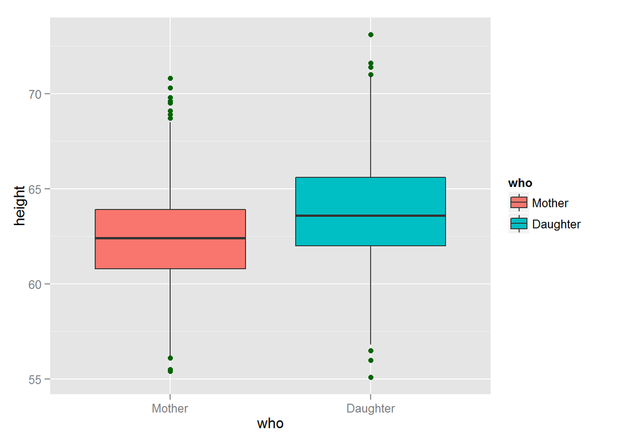

```r
require(ggplot2)
heightStack <- data.frame(height = c(heights$Mheight,heights$Dheight),who = factor(c(rep("Mother",1375),rep("Daughter",1375)),levels=c("Mother","Daughter")))
ggplot(heightStack,aes(who,height)) + geom_boxplot(outlier.colour="darkgreen",aes(fill=who))
```

Now we’ll do a scatter plot of mother’s heights versus daughter’s heights. The first line in the code below changes the theme. qplot acts similarly to base R command plot.

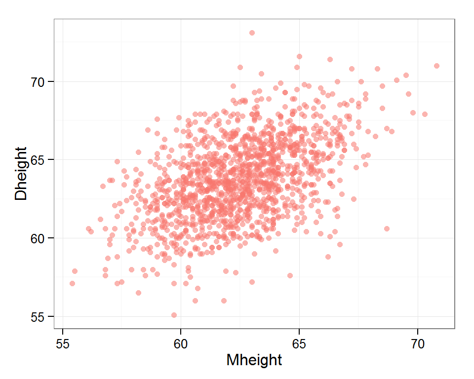

```r
theme_set(theme_bw()) ## sets default white background theme for ggplot
qplot(Mheight, Dheight, data=heights, col="red", alpha=.5) + theme(legend.position="none")
```

We can also do this using ggplot.

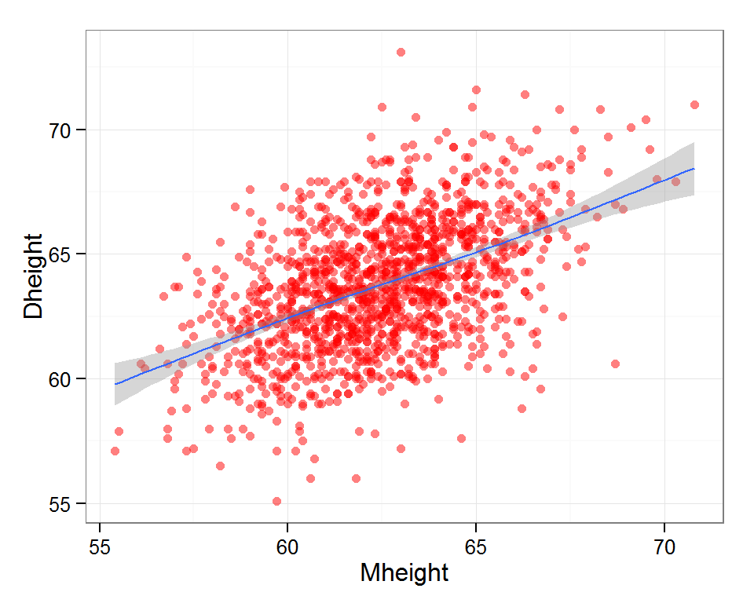

```r
theme_set(theme_bw()) ## sets default white background theme for ggplot
ggplot(heights,aes(Mheight, Dheight)) + geom_point(col="red",alpha=0.5) + stat_smooth()
```